# Module 3 Assignment Solutions

Jessica Cooperstone

Due 10-28-2022

## Introduction

This is your assignment for Module 3 Data Exploration, focused on the material you learned in the lectures and recitation activities on data distributions, correlations, and annotating statistics.

Submission info:

- Please submit this assignment by uploading a **knitted .html** to Carmen
- Your headers should be logical and your report and code annotated with descriptions of what you’re doing
- Make sure you include the Code Download button so that I can see your code as well
- Customize the YAML and the document so you like how it looks

Remember there are often many ways to reach the same end product. I have showed you many ways in class to achieve a similar end product, you only need to show me one of them. As long as your answer is reasonable, you will get full credit even if its different than what I intended.

> This assignment will be due on Friday, October 28, 2022, at 11:59pm.

### Data

The [data](https://github.com/rfordatascience/tidytuesday/blob/master/data/2020/2020-03-10/readme.md) we will be using was collected by the US Department of Education and collated by [tuitiontracker.org](https://www.tuitiontracker.org/). You can learn more about the data by going through the readme [here](https://github.com/rfordatascience/tidytuesday/blob/master/data/2020/2020-03-10/readme.md).

```r
tuition_cost <- readr::read_csv('https://raw.githubusercontent.com/rfordatascience/tidytuesday/master/data/2020/2020-03-10/tuition_cost.csv')

salary_potential <- readr::read_csv('https://raw.githubusercontent.com/rfordatascience/tidytuesday/master/data/2020/2020-03-10/salary_potential.csv')
```

For a little hint, here are the packages I used to complete this task. Yours might not be exactly the same.

```r
library(tidyverse)
library(scales)
library(ggridges)
library(ggdist)
library(ggpubr)
library(rstatix)
library(corrplot)
library(Hmisc)
```

## 1. Data distributions visualization (3 pts)

Create a visualization that shows the distribution of tuition costs (both `in_state_tuition` and `out_of_state_tuition`) across public, private, and for-profit universities and colleges. You can use whatever type of plot you think is appropriate to show this distribution across different types of universities. Your plot should be publication ready quality.

### Wrangle

```r
# wrangle data to be in tidy format for in state and out of state tuition
# to facet, the faceting variable needs to be in one column
tuition_cost_tidy <- tuition_cost %>%
  pivot_longer(cols = c(in_state_tuition, out_of_state_tuition),
               names_to = "state_type",
               values_to = "tuition")
```

### Adjust labels

```r
# make a vector that has all the full names as wanted to appear in strip text
state_type_labels <- c("In state tuition", "Out of state tuition")

# tell state_type_labels which original label to refer to
names(state_type_labels) <- c("in_state_tuition", "out_of_state_tuition")
```

### Plot

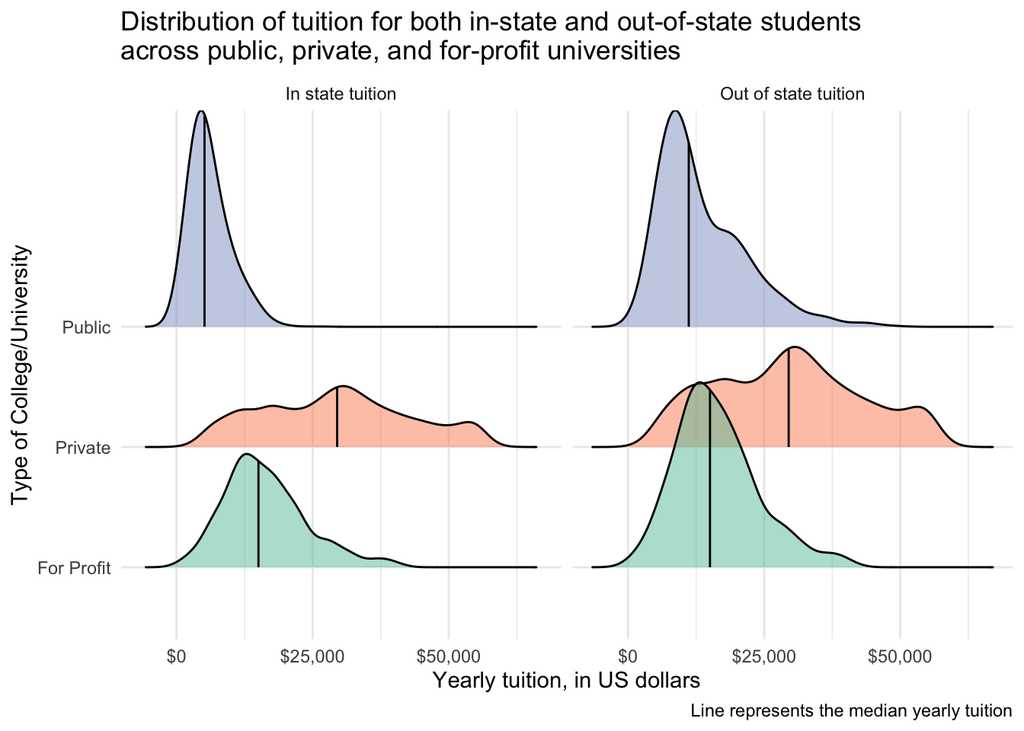

```r
# plot
tuition_cost_tidy %>%
  filter(type != "Other") %>%
  ggplot(aes(x = tuition, y = type, fill = type)) +
  stat_density_ridges(quantile_lines = TRUE,
                      quantiles = 2,
                      alpha = 0.5) +
  scale_x_continuous(labels = dollar) +
  scale_fill_brewer(palette = "Set2") +
  facet_wrap(vars(state_type),
             labeller = labeller(state_type = state_type_labels)) +
  theme_minimal() +
  theme(legend.position = "none") +
  labs(x = "Yearly tuition, in US dollars",
       y = "Type of College/University",
       title = "Distribution of tuition for both in-state and out-of-state students \nacross public, private, and for-profit universities",
       caption = "Line represents the median yearly tuition")
```

## 2. Adding statistics visualization (4 pts)

Make a plot that shows the difference in `early_career_pay` across private and public universities/colleges. Is there any statistical difference in pay across these two categories of institutions? Is the same true for `mid_career_pay`? This can be either one or two plots, its up to you. Make sure you are doing the right statistical test appropriate for your data.

### Join tuition_cost and salary_potential

```r
salary_cost_join <- left_join(tuition_cost, salary_potential,
                              by = "name")
```